# Encrypted Handwriting Recognition Report

```python
import os
import torch
import torch.nn as nn
import torch.nn.functional as F
from torchvision import datasets, transforms
from torchvision.utils import save_image
import fhetorch
from fhetorch.op.CipherUtil import encrypt_tensor, decrypt_tensor
import time
from collections import defaultdict
from fvcore.nn import parameter_count_table
from torchinfo import summary
import torchtrail
```

```
Info: init sk success.
```

### 1. Simple Architecture of CNN (Convolutional Neural Networks)

- Convolution Operation

> The core concept behind CNN(Convolutional Neural Network) comes from the convolution operation, which plays a fundamental role in data processing tasks like image recognition.

The main purpose of convolution is to extract features and isolate important details from the input image； By sliding filters (small matrixes) over the input matrix of pixel value, the neural network can better understand and classify features within the images； During the convolution operation, these filters also preserve the spatial relationship between pixels, which ensures the structural integrity of the image, which is crucial for recognizing patterns and objects.

```python
class Net(nn.Module):
    def __init__(self):
        super(Net, self).__init__()
        self.conv1 = nn.Conv2d(1, 10, 3, 1)
        self.conv2 = nn.Conv2d(10, 20, 3, 1)
        self.fc1 = nn.Linear(2880, 128)
        self.fc2 = nn.Linear(128, 10)

    def forward(self, x):
        x = self.conv1(x)
        x = F.relu(x)
        x = self.conv2(x)
        x = F.relu(x)
        x = F.max_pool2d(x, 2)
        x = torch.flatten(x, 1)
        x = self.fc1(x)
        x = F.relu(x)
        x = self.fc2(x)
        output = F.log_softmax(x, dim=1)
        return output

# print(f"=== Parameter Quantity:")
# print(parameter_count_table(Net()))
# print(f"=== Statistics:")
# summary(Net(), input_size=(1, 1, 28, 28))
```

### 2. Handwritten Dataset

- `mnist`Dataset Composition

All images have been normalized and centered, scaling down the pixel values so that they fall within the range from 0 to 1, and the mean is close to 0.

Each single image is actually a matrix composed of pixel values:

[figure not shown]

In image processing, a channel refers to a specific part of the image data. For example,

```
- Digital cameras capture images using the RGB color model, which consists of three channels: Red, Green, and Blue. You can visualize different color components as three stacked 2D matrices, each representing different intensities of color. In this representation, each pixel value ranges from 0 to 255.

- A grayscale image has only a single channel.
```

For simplicity, this research will only consider grayscale images. This means we will have a 2D matrix to express the grayscale image, where pixel values range from 0 to 255 with 0 represents pure black, and 255 represents pure white.

- `mnist` Reading

  prepare_model_and_data Function
  - do_train=True

  This option enables training in plaintext and saves the model parameters to `mnist.pt.`
  - do_train=False

  This option is used to only read the data without performing any training.

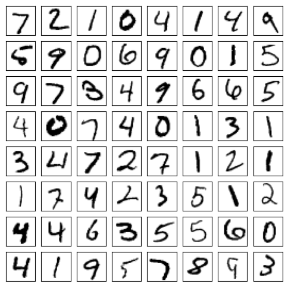

```python
from matplotlib import pyplot as plt

def prepare_model_and_data(store="./data",
                           do_train=False,
                           batch_size=32,
                           epochs=5):
    """Dataset Initialization
    """
    if not os.path.exists(store):
        os.mkdir(store)

    trans = transforms.Compose([
        transforms.ToTensor(),
        transforms.Normalize((0.1307,), (0.3081,))
    ])

    test_set = datasets.MNIST(
            root=store,
            train=False,
            transform=trans,
            download=True)

    test_loader = torch.utils.data.DataLoader(
            dataset=test_set,
            batch_size=batch_size,
            shuffle=False)

    if do_train:
        train_set = datasets.MNIST(
            root=store,
            train=True,
            transform=trans,
            download=True)

        train_loader = torch.utils.data.DataLoader(
            dataset=train_set,
            batch_size=batch_size,
            shuffle=True)

        model = Net().to('cpu')
        optimizer = torch.optim.SGD(model.parameters(), lr=0.01, momentum=0.9)

        for epoch in range(1, epochs+1): # trainning
            model.train()
            for batch_idx, (data, target) in enumerate(train_loader):
                data, target = data.to('cpu'), target.to('cpu')
                optimizer.zero_grad()
                output = model(data)
                loss = F.nll_loss(output, target)
                loss.backward()
                optimizer.step()
                if batch_idx % 100 == 0 \
                    or batch_idx + 1 == len(train_loader):
                    print('Train Epoch: {} [{}/{} ({:.0f}%)]\tLoss: {:.6f}'.format(
                        epoch, batch_idx * len(data), len(train_loader.dataset),
                        100. * batch_idx / len(train_loader), loss.item()))

            model.eval()
            test_loss = 0
            correct = 0
            with torch.no_grad():
                for data, target in test_loader:
                    data, target = data.to('cpu'), target.to('cpu')
                    output = model(data)
                    test_loss += F.nll_loss(output, target, reduction='sum').item()  # sum up batch loss
                    pred = output.argmax(dim=1, keepdim=True)  # get the index of the max log-probability
                    correct += pred.eq(target.view_as(pred)).sum().item()

            test_loss /= len(test_loader.dataset)

            print('\nTest set: Average loss: {:.4f}, Accuracy: {}/{} ({:.0f}%)\n'.format(
                test_loss, correct, len(test_loader.dataset),
                100. * correct / len(test_loader.dataset)))

        ck = {
            'model': model,
            'model_state_dict': model.state_dict(),
        }
        torch.save(ck, "./data/mnist.pt")

    return test_loader

# when train:
# data_loader = prepare_model_and_data(do_train=True)

# # Draw Numbers
data_loader_plot = prepare_model_and_data(do_train=False, batch_size=1)
fig, ax = plt.subplots(8, 8, figsize=(6,6))
idx = 0
for data, target in data_loader_plot:
    if idx >= 64:
        break
    ax.flat[idx].imshow(data[0][0], cmap='binary')
    ax.flat[idx].set(xticks=[], yticks=[])
    idx += 1

plt.show()
```

### 3. Ciphertext CNN Architecture

- Standard CNN layers are replaced with their counterparts from a library designed for homomorphic encryption or secure computations, such as FHEtorch. For example, `Conv2D` -> `HeConv2D.`
- Layer Parameters remain consistent.
- In a Ciphertext CNN, the calculations for non-parametric layers (i.e. activation functions) must be replaced with the corresponding functions from the fhetorch library, to ensure that they can work with encrypted data while maintaining the intended behavior of the original operations.

```python
class CipherNet(nn.Module):
    def __init__(self):
        super(CipherNet, self).__init__()
        self.hconv1 = fhetorch.HeConv2D(1, 10, (3, 3), 1)
        self.hconv2 = fhetorch.HeConv2D(10, 20, (3, 3), 1)
        self.hfc1 = fhetorch.HeLinear(2880, 128)
        self.hfc2 = fhetorch.HeLinear(128, 10)

    def forward(self, x):
        x = self.hconv1(x)
        x = fhetorch.hrelu(x)
        x = self.hconv2(x)
        x = fhetorch.hrelu(x)
        x = fhetorch.hmaxpool_2d(x, 2)
        x = fhetorch.hflatten(x, 1)
        x = self.hfc1(x)
        x = fhetorch.hrelu(x)
        x = self.hfc2(x)
        output = fhetorch.hlog_softmax(x, dim=1)
        return output
```

### 4. Ciphertext Images

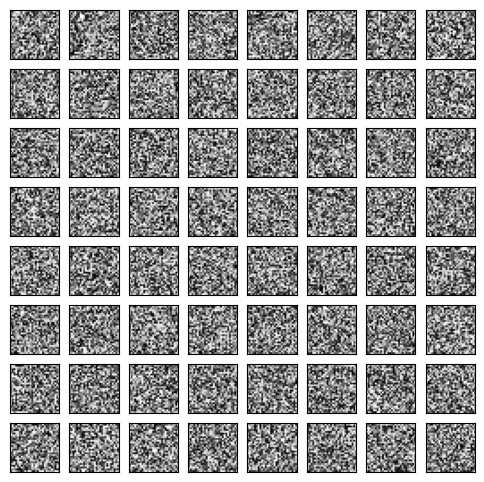

```python
data_loader_plot2 = prepare_model_and_data(do_train=False, batch_size=1)
fig, ax = plt.subplots(8, 8, figsize=(6,6))
idx = 0
for data, target in data_loader_plot2:
    if idx >= 64:
        break
    data_enc = encrypt_tensor(data[0][0]).sum(axis=-1) % 255
    ax.flat[idx].imshow(data_enc, cmap='binary')
    ax.flat[idx].set(xticks=[], yticks=[])
    idx += 1

plt.show()
```

### 5. Plaintext Model Initialization

- `mnist.pt` refers to the saved parameters of a previously trained model. After loading it using load_state_dict, the model is set to evaluation mode using eval, resulting in the plaintext model.
- After loading the model parameters, the structure of the plaintext model is printed out as follows. It’s noted that the time cost is mainly in the `conv2d` operations.

```python
ck_ori = torch.load("./data/mnist.pt")
# Extract Network Structure
model_ori = ck_ori['model']
# Load Network Weight Parameters
model_ori.load_state_dict(ck_ori['model_state_dict'])
for parameter in model_ori.parameters():
    parameter.requires_grad = False
model_ori.eval()

with torchtrail.trace():
    input_tensor, _ = next(iter(data_loader_plot))
    output_tensor = model_ori(input_tensor)

torchtrail.visualize(output_tensor,
    graph_attr={"ordering": "out", "rankdir": "TB", "ranksep": "0.5"},
    node_attr = {
        "style": "filled",
        "border": "0.1",
        "fontsize": "8",
        "height": "0.08",
        "fontname": "Linux libertine",
        "margin": "0",
        "shape": "none",
    }, edge_attr = {
        "fontsize": "8",
        "arrowsize": "0.25",
    })
```

[figure not shown]

### 6. Ciphertext Model Initialization

Two methods:

- Real-time Conversion: For each layer, call`encrypt_tensor`to obtain the ciphertext parameters.
- Recovery from File: `cipher_mnist.pt` is the file that stores the pre-converted parameters for each layer. Load them directly.

```python
fhetorch.initDict()
model_cipher = CipherNet().to('cpu')

param_dict = torch.load('./data/cipher_mnist.pt')

print("=== Convert conv1 =====")
model_cipher.hconv1.weight = torch.nn.Parameter(param_dict['v1'], requires_grad=False)
model_cipher.hconv1.bias = torch.nn.Parameter(param_dict['v2'], requires_grad=False)

print("=== Convert conv2 =====")
model_cipher.hconv2.weight = torch.nn.Parameter(param_dict['v3'], requires_grad=False)
model_cipher.hconv2.bias = torch.nn.Parameter(param_dict['v4'], requires_grad=False)

print("=== Convert fc1 =====")
model_cipher.hfc1.weight = torch.nn.Parameter(param_dict['v5'], requires_grad=False)
model_cipher.hfc1.bias = torch.nn.Parameter(param_dict['v6'], requires_grad=False)

print("=== Convert fc2 =====")
model_cipher.hfc2.weight = torch.nn.Parameter(param_dict['v7'], requires_grad=False)
model_cipher.hfc2.bias = torch.nn.Parameter(param_dict['v8'], requires_grad=False)

model_cipher.eval()

# when infer:
data_loader = prepare_model_and_data(do_train=False, batch_size=1)
print(f"fhetorchParameter Quantity:")
print(parameter_count_table(model_cipher))
print(f"fhetorch Statistics::")
print(summary(model_cipher, input_size=(1, 1, 28, 28, 5), dtypes=[torch.float64]))
```

```
/liuchiyu/fhetorch/fhetorch/file/dictf3.3 /liuchiyu/fhetorch/fhetorch/file/user_info /liuchiyu/fhetorch/fhetorch/file/user_info_skb
Hello,  chiyuliu
Serial number verification succeeded! 80 days left to expiration.
Info: init dict success.
=== Convert conv1 =====
=== Convert conv2 =====
=== Convert fc1 =====
=== Convert fc2 =====
fhetorch Parameter Quantity:
| name            | #elements or shape   |
|:----------------|:---------------------|
| model           | 1.9M                 |
|  hconv1         |  0.5K                |
|   hconv1.weight |   (10, 1, 3, 3, 5)   |
|   hconv1.bias   |   (10, 5)            |
|  hconv2         |  9.1K                |
|   hconv2.weight |   (20, 10, 3, 3, 5)  |
|   hconv2.bias   |   (20, 5)            |
|  hfc1           |  1.8M                |
|   hfc1.weight   |   (128, 2880, 5)     |
|   hfc1.bias     |   (128, 5)           |
|  hfc2           |  6.5K                |
|   hfc2.weight   |   (10, 128, 5)       |
|   hfc2.bias     |   (10, 5)            |
fhetorch统计:
==========================================================================================
Layer (type:depth-idx)                   Output Shape              Param #
==========================================================================================
CipherNet                                [1, 10, 5]                --
├─HeConv2D: 1-1                          [1, 10, 26, 26, 5]        (500)
├─HeConv2D: 1-2                          [1, 20, 24, 24, 5]        (9,100)
├─HeLinear: 1-3                          [1, 128, 5]               (1,843,840)
├─HeLinear: 1-4                          [1, 10, 5]                (6,450)
==========================================================================================
Total params: 1,859,890
Trainable params: 0
Non-trainable params: 1,859,890
Total mult-adds (Units.MEGABYTES): 29.75
==========================================================================================
Input size (MB): 0.03
Forward/backward pass size (MB): 1.47
Params size (MB): 14.88
Estimated Total Size (MB): 16.38
==========================================================================================
```

```python
import sys
import pandas as pd
records = []
n = 0
with torch.no_grad():
    for data, target in data_loader:
        data, target = data.to('cpu'), target.to('cpu')
        record = {}
        record["orinelemnt"] = data.cpu().element_size() * data.cpu().nelement()
        record["orishape"] = list(data.shape)
        record["target"] = target.numpy()[0]
        start_1 = time.time()
        predict_ori = model_ori(data)
        end_1 = time.time()
        record["oritime"] = end_1 - start_1

        data_enc = encrypt_tensor(data).to('cpu')
        record["encnelemnt"] = data_enc.element_size() * data_enc.nelement()
        record["encshape"] = list(data_enc.shape)

        start_2 = time.time()
        predict_cipher = model_cipher(data_enc)
        end_2 = time.time()
        record["enctime"] = end_2 - start_2

        res = decrypt_tensor(predict_cipher)
        record["orires"] = int(predict_ori.argmax())
        record["encres"] = int(res.argmax())
        records.append(record)
        n += 1
        if n > 100:
            break
df = pd.DataFrame(records)
df
```

|  | orinelemnt | orishape | target | oritime | encnelemnt | encshape | enctime | orires | encres |
| --- | --- | --- | --- | --- | --- | --- | --- | --- | --- |
| 0 | 3136 | [1, 1, 28, 28] | 7 | 0.000555 | 31360 | [1, 1, 28, 28, 5] | 0.051203 | 7 | 7 |
| 1 | 3136 | [1, 1, 28, 28] | 2 | 0.000447 | 31360 | [1, 1, 28, 28, 5] | 0.051704 | 2 | 2 |
| 2 | 3136 | [1, 1, 28, 28] | 1 | 0.000433 | 31360 | [1, 1, 28, 28, 5] | 0.048399 | 1 | 1 |
| 3 | 3136 | [1, 1, 28, 28] | 0 | 0.000388 | 31360 | [1, 1, 28, 28, 5] | 0.054265 | 0 | 0 |
| 4 | 3136 | [1, 1, 28, 28] | 4 | 0.000424 | 31360 | [1, 1, 28, 28, 5] | 0.051701 | 4 | 4 |
| ... | ... | ... | ... | ... | ... | ... | ... | ... | ... |
| 96 | 3136 | [1, 1, 28, 28] | 1 | 0.000351 | 31360 | [1, 1, 28, 28, 5] | 0.051948 | 1 | 1 |
| 97 | 3136 | [1, 1, 28, 28] | 7 | 0.000355 | 31360 | [1, 1, 28, 28, 5] | 0.056538 | 7 | 7 |
| 98 | 3136 | [1, 1, 28, 28] | 6 | 0.000412 | 31360 | [1, 1, 28, 28, 5] | 0.050330 | 6 | 6 |
| 99 | 3136 | [1, 1, 28, 28] | 9 | 0.000361 | 31360 | [1, 1, 28, 28, 5] | 0.050899 | 9 | 9 |
| 100 | 3136 | [1, 1, 28, 28] | 6 | 0.000354 | 31360 | [1, 1, 28, 28, 5] | 0.053946 | 6 | 6 |

101 rows × 9 columns

### Accuracy

- **Accuracy is consistent with plaintext**

```python
import numpy as np
dff1 = df.groupby(['target']).mean(["oritime", "orinelemnt",  "enctime", "encnelemnt"])[["oritime", "orinelemnt",  "enctime", "encnelemnt"]]
dff2 = df.groupby(['target']).apply(lambda x: pd.Series({
        "oritrue": np.sum(x["orires"] == x["target"]),
        "orifalse": np.sum(x["orires"] != x["target"]),
        "oriacc": np.sum(x["orires"] == x["target"]) / len(x["target"]),
        "ciphertrue": np.sum(x["encres"] == x["target"]),
        "cipherfalse": np.sum(x["encres"] != x["target"]),
        "cipheracc": np.sum(x["encres"] == x["target"]) / len(x["target"])
       }))
dff1.join(dff2)
```

| target | oritime | orinelemnt | enctime | encnelemnt | oritrue | orifalse | oriacc | ciphertrue | cipherfalse | cipheracc |
| --- | --- | --- | --- | --- | --- | --- | --- | --- | --- | --- |
| 0 | 0.000373 | 3136.0 | 0.054264 | 31360.0 | 8.0 | 0.0 | 1.000000 | 8.0 | 0.0 | 1.000000 |
| 1 | 0.000387 | 3136.0 | 0.053293 | 31360.0 | 14.0 | 0.0 | 1.000000 | 14.0 | 0.0 | 1.000000 |
| 2 | 0.000389 | 3136.0 | 0.054318 | 31360.0 | 8.0 | 0.0 | 1.000000 | 8.0 | 0.0 | 1.000000 |
| 3 | 0.000379 | 3136.0 | 0.050731 | 31360.0 | 11.0 | 0.0 | 1.000000 | 11.0 | 0.0 | 1.000000 |
| 4 | 0.000382 | 3136.0 | 0.052733 | 31360.0 | 14.0 | 0.0 | 1.000000 | 14.0 | 0.0 | 1.000000 |
| 5 | 0.000374 | 3136.0 | 0.051522 | 31360.0 | 7.0 | 0.0 | 1.000000 | 7.0 | 0.0 | 1.000000 |
| 6 | 0.000387 | 3136.0 | 0.053037 | 31360.0 | 11.0 | 0.0 | 1.000000 | 11.0 | 0.0 | 1.000000 |
| 7 | 0.000387 | 3136.0 | 0.054988 | 31360.0 | 15.0 | 0.0 | 1.000000 | 15.0 | 0.0 | 1.000000 |
| 8 | 0.000367 | 3136.0 | 0.052796 | 31360.0 | 2.0 | 0.0 | 1.000000 | 2.0 | 0.0 | 1.000000 |
| 9 | 0.000382 | 3136.0 | 0.052421 | 31360.0 | 10.0 | 1.0 | 0.909091 | 10.0 | 1.0 | 0.909091 |